# Development and Implementation of an ML-Powered Market-Making Algorithm for Equity Markets

This notebook presents an advanced AI-powered algorithm designed to optimize market-making strategies in the stock market. By leveraging historical market data and sophisticated machine learning techniques, the algorithm aims to enhance trading performance through accurate price predictions, efficient portfolio management, and risk mitigation. The key components of the notebook include data collection, feature engineering, model training, backtesting, and performance evaluation.

The primary goal of this project is to demonstrate my skills and knowledge in strategy and model development, quatitative finance acumen, backtesting, and data science.

1. Introduction
2. Data Collection and Preprocessing
3. Feature Engineering
4. Model Development
5. Backtesting
6. Portfolio Construction and Performance Evaluation
7. Conclusion and Next Steps

## 1. Introduction

In the development of this AI-driven trading strategy, a robust foundation is crucial for identifying effective market signals. To this end, I have researched and utilized the seminal work of McLean and Pontiff (2016). Their comprehensive study provides an extensive list of predictive signals that can be categorized into four broad types: Event, Market, Valuation, and Fundamental.

#### McLean and Pontiff (2016) Signals:

| Event | Market | Valuation | Fundamental |
| --- | --- | --- | --- |
| Change in Asset Turnover | 52-Week High | Advertising/MV | Accruals |
| Change in Profit Margin | Age-Momentum | Analyst Value | Age |
| Change in Recommendation | Amihud's Measure | Book-to-Market | Asset Growth |
| Chg. Forecast + Accrual | Beta | Cash Flow/MV | Asset Turnover |
| Debt Issuance | Bid/Ask Spread | Dividends | Cash Flow Variance |
| Dividend Initiation | Coskewness | Earnings-to-Price | Earnings Consistency |
| Dividend Omission | Idiosyncratic Risk | Enterprise Component of B/P | Forecast Dispersion |
| Dividends | Industry Momentum | Enterprise Multiple | G Index |
| Down Forecast | Lagged Momentum | Leverage Component of B/P | Gross Profitability |
| Exchange Switch | Long-term Reversal | Marketing/MV | G-Score |
| Growth in Inventory | Max | Org. Capital | G-Score 2 |
| Growth in LTNOA | Momentum | R&D/MV | Herfindahl |
| IPO | Momentum and Long-term Reversal | Sales/Price | Investment |
| IPO + Age | Momentum-Ratings |  | Leverage |
| IPO no R&D | Momentum-Reversal |  | M/B and Accruals |
| Mergers | Price |  | NOA |
| Post Earnings Drift | Seasonality |  | Operating Leverage |
| R&D Increases | Short Interest |  | O-Score |
| Ratings Downgrades | Short-term Reversal |  | Pension Funding |
| Repurchases | Size |  | Percent Operating Accrual |
| Revenue Surprises | Volume |  | Percent Total Accrual |
| SEOs | Volume Trend |  | Profit Margin |
| Share Issuance 1-Year | Volume Variance |  | Profitability |
| Share Issuance 5-Year | Volume-Momentum |  | ROE |
| Spinoffs | Volume/MV |  | Sales Growth |
| Sustainable Growth |  |  | Tax |
| Total External Finance |  |  | Z-Score |
| Up Forecast |  |  |  |
| ΔCapex - ΔIndustry CAPEX |  |  |  |
| ΔNoncurrent Op. Assets |  |  |  |
| ΔSales - ΔInventory |  |  |  |
| ΔSales - ΔSG&A |  |  |  |
| ΔWork. Capital |  |  |  |

We are particularly interested in market-moving indicators. Therefore, we will focus on the Event and Market columns for our research. Since the primary goal of this project is to demonstrate my quantitative finance skills, I chose to simplify the model development process by only considering those indicators from the two columns that can be directly obtained or derived from the data pulled through `yfinance`.

What wewill use, are the following:

| Type | Metrics and Events |
| --- | --- |
| **Price and Volume Data** |  |
|  | 52-Week High |
|  | Beta |
|  | Bid/Ask Spread |
|  | Price |
|  | Size (Market Capitalization) |
|  | Volume |
|  | Volume Trend (derived) |
|  | Volume Variance (derived) |
|  | Volume-Momentum (derived) |
|  | Volume/MV (derived) |
| **Financial Metrics and Events** |  |
|  | Dividends |
|  | IPO Information |
|  | Share Issuance 1-Year/5-Year (requires processing historical data) |
| **Derived Metrics** |  |
|  | Momentum |
|  | Lagged Momentum |
|  | Seasonality (based on historical prices) |
|  | Long-term Reversal |
|  | Short-term Reversal |
|  | Idiosyncratic Risk (requires advanced calculations) |
|  | Industry Momentum (requires sector analysis) |
|  | Age-Momentum (requires additional historical data processing) |

```python
# Uncomment the line below before running
# pip install -U yfinance PyPortfolioOpt xgboost
```

```python
import yfinance as yf
import pandas as pd
import numpy as np
from statsmodels.regression.linear_model import OLS
import matplotlib.pyplot as plt
from sklearn.model_selection import train_test_split
from sklearn.ensemble import RandomForestRegressor
from sklearn.metrics import mean_squared_error
from sklearn.compose import ColumnTransformer
from sklearn.pipeline import Pipeline
from sklearn.preprocessing import StandardScaler
from sklearn.decomposition import PCA
from sklearn.model_selection import RandomizedSearchCV
from sklearn.feature_selection import RFECV, RFE
from sklearn.linear_model import LinearRegression, Ridge
from sklearn.model_selection import KFold
from sklearn.ensemble import RandomForestRegressor, GradientBoostingRegressor
from sklearn.tree import DecisionTreeRegressor
import xgboost as xgb
from sklearn.metrics import mean_squared_error
from sklearn.metrics import r2_score
import seaborn as sns
import cvxpy as cp
from pypfopt import expected_returns, risk_models, EfficientFrontier, plotting
from pypfopt.discrete_allocation import DiscreteAllocation, get_latest_prices
from pypfopt.plotting import plot_efficient_frontier
import joblib
import warnings

warnings.filterwarnings('ignore')
```

## 2. Data Collection and Preprocessing

```python
tickers = ["AAPL", "MSFT", "GOOG", "NVDA"] # Arbitrary
period = "5y"
start_date = "2019-07-04"
end_date = "2024-07-03"

def get_stock_data(ticker, start_date, end_date):
    stock = yf.Ticker(ticker)
    hist = stock.history(start=start_date, end=end_date)
    return hist

stock_data = {ticker: get_stock_data(ticker, start_date, end_date) for ticker in tickers}

stock_data['AAPL'].head()
```

| Date | Open | High | Low | Close | Volume | Dividends | Stock Splits |
| --- | --- | --- | --- | --- | --- | --- | --- |
| 2019-07-05 00:00:00-04:00 | 49.063133 | 49.480536 | 48.954556 | 49.275452 | 69062000 | 0.0 | 0.0 |
| 2019-07-08 00:00:00-04:00 | 48.450294 | 48.592645 | 47.871238 | 48.259689 | 101354400 | 0.0 | 0.0 |
| 2019-07-09 00:00:00-04:00 | 48.061837 | 48.619180 | 47.967741 | 48.554039 | 82312000 | 0.0 | 0.0 |
| 2019-07-10 00:00:00-04:00 | 48.701220 | 49.154813 | 48.631248 | 49.034176 | 71588400 | 0.0 | 0.0 |
| 2019-07-11 00:00:00-04:00 | 49.053477 | 49.314054 | 48.667440 | 48.677090 | 80767200 | 0.0 | 0.0 |

## 3. Feature Engineering

We have identified key features that impact market movements above. Some of them require derivation and processing.

#### Feature Definitions

- **52_Week_High**: The highest closing price of the stock over the past 52 weeks.
- **Momentum**: The percentage change in the stock's closing price over the past 21 trading days.
- **Lagged_Momentum**: Momentum shifted by 21 days to capture past performance trends.
- **Volume_Trend**: The 21-day moving average of the stock's trading volume.
- **Volume_Variance**: The variance of the stock's trading volume over the past 21 days.
- **Volume_Momentum**: The percentage change in the stock's trading volume over the past 21 days.
- **Volume_MV**: The ratio of the stock's trading volume to its market capitalization.
- **Long_Term_Reversal**: The percentage change in the stock's closing price over the past 252 trading days, indicating mean reversion tendencies.
- **Short_Term_Reversal**: The percentage change in the stock's closing price over the past 5 trading days, indicating short-term mean reversion.
- **Beta**: A measure of the stock's volatility relative to the market.
- **Market_Cap**: The total market value of the company's outstanding shares.
- **Seasonality**: The average closing price of the stock for each month, capturing seasonal trends.
- **Idiosyncratic_Risk**: The standard deviation of the residuals from the regression of the stock's returns against market returns, indicating risk specific to the stock.
- **Sector_Momentum**: The percentage change in the closing price of the sector ETF (e.g., Technology Select Sector SPDR Fund) over the past 21 trading days, capturing the momentum of the sector to which the stock belongs.

These features provide a comprehensive view of various aspects of the stock's performance and are used to enhance the predictive power of our models.

```python
def generate_features(hist, market_cap, beta):
    hist['52_week_high'] = hist['Close'].rolling(window=252).max()
    hist['momentum'] = hist['Close'] / hist['Close'].shift(21) - 1
    hist['lagged_momentum'] = hist['momentum'].shift(21)
    hist['volume_trend'] = hist['Volume'].rolling(window=21).mean()
    hist['volume_variance'] = hist['Volume'].rolling(window=21).var()
    hist['volume_momentum'] = hist['Volume'] / hist['Volume'].shift(21) - 1
    hist['volume_mv'] = hist['Volume'] / market_cap
    hist['long_term_reversal'] = hist['Close'].shift(252) / hist['Close'] - 1
    hist['short_term_reversal'] = hist['Close'].shift(5) / hist['Close'] - 1
    hist['beta'] = beta
    hist['market_cap'] = market_cap
    hist['seasonality'] = hist['Close'].groupby(hist.index.month).transform('mean')
    # Idiosyncratic Risk (assuming S&P 500 as market proxy)
    market_returns = yf.Ticker('^GSPC').history(period=period)['Close'].pct_change().dropna()
    stock_returns = hist['Close'].pct_change().dropna()
    combined = pd.concat([stock_returns, market_returns], axis=1).dropna()
    combined.columns = ['Stock', 'Market']
    from statsmodels.regression.linear_model import OLS
    model = OLS(combined['Stock'], combined['Market']).fit()
    hist['idiosyncratic_risk'] = model.resid.std()
    # Industry Momentum
    sector_ticker = yf.Ticker('XLK')  # Technology Select Sector SPDR Fund
    sector_hist = sector_ticker.history(period=period)
    sector_hist['sector_momentum'] = sector_hist['Close'] / sector_hist['Close'].shift(21) - 1
    hist = hist.join(sector_hist['sector_momentum'], rsuffix='_sector')
    return hist

# Additional information for beta and market cap
def get_additional_info(ticker):
    stock = yf.Ticker(ticker)
    summary = stock.info
    market_cap = summary['marketCap']
    beta = summary['beta']
    return market_cap, beta

for ticker in tickers:
    market_cap, beta = get_additional_info(ticker)
    stock_data[ticker] = generate_features(stock_data[ticker], market_cap, beta)

stock_data['AAPL'].head()
```

| Date | Open | High | Low | Close | Volume | Dividends | Stock Splits | 52_week_high | momentum | lagged_momentum | ... | volume_variance | volume_momentum | volume_mv | long_term_reversal | short_term_reversal | beta | market_cap | seasonality | idiosyncratic_risk | sector_momentum |
| --- | --- | --- | --- | --- | --- | --- | --- | --- | --- | --- | --- | --- | --- | --- | --- | --- | --- | --- | --- | --- | --- |
| 2019-07-05 00:00:00-04:00 | 49.063133 | 49.480536 | 48.954556 | 49.275452 | 69062000 | 0.0 | 0.0 | NaN | NaN | NaN | ... | NaN | NaN | 0.000020 | NaN | NaN | 1.25 | 3397269848064 | 127.089238 | 0.012146 | NaN |
| 2019-07-08 00:00:00-04:00 | 48.450294 | 48.592645 | 47.871238 | 48.259689 | 101354400 | 0.0 | 0.0 | NaN | NaN | NaN | ... | NaN | NaN | 0.000030 | NaN | NaN | 1.25 | 3397269848064 | 127.089238 | 0.012146 | NaN |
| 2019-07-09 00:00:00-04:00 | 48.061837 | 48.619180 | 47.967741 | 48.554039 | 82312000 | 0.0 | 0.0 | NaN | NaN | NaN | ... | NaN | NaN | 0.000024 | NaN | NaN | 1.25 | 3397269848064 | 127.089238 | 0.012146 | NaN |
| 2019-07-10 00:00:00-04:00 | 48.701220 | 49.154813 | 48.631248 | 49.034176 | 71588400 | 0.0 | 0.0 | NaN | NaN | NaN | ... | NaN | NaN | 0.000021 | NaN | NaN | 1.25 | 3397269848064 | 127.089238 | 0.012146 | NaN |
| 2019-07-11 00:00:00-04:00 | 49.053477 | 49.314054 | 48.667440 | 48.677090 | 80767200 | 0.0 | 0.0 | NaN | NaN | NaN | ... | NaN | NaN | 0.000024 | NaN | NaN | 1.25 | 3397269848064 | 127.089238 | 0.012146 | NaN |

5 rows × 21 columns

For this project, I will **predict the Next Day's Closing Price**.

#### Understanding:

- **Foreward Looking Relevance:** Useful for traders to make future buy/sell/hold decisions.
- **Feasibility:** Influenced by short-term factors captured in daily trading data.
- **Simplicity:** It offers a straightforward evaluation of model performance, as actual next day prices are easily obtainable.
- **Short-Term Trading:** It aligns well with short-term trading and market making activities, providing immediate insights for trading decisions.

```python
for ticker in stock_data.keys():
    stock_data[ticker]['Next_Close'] = stock_data[ticker]['Close'].shift(-1)

stock_data = {ticker: data.dropna() for ticker, data in stock_data.items()}

combined_data = pd.concat(stock_data.values(), keys=stock_data.keys())
stock_data['AAPL'].head()
```

| Date | Open | High | Low | Close | Volume | Dividends | Stock Splits | 52_week_high | momentum | lagged_momentum | ... | volume_momentum | volume_mv | long_term_reversal | short_term_reversal | beta | market_cap | seasonality | idiosyncratic_risk | sector_momentum | Next_Close |
| --- | --- | --- | --- | --- | --- | --- | --- | --- | --- | --- | --- | --- | --- | --- | --- | --- | --- | --- | --- | --- | --- |
| 2020-07-06 00:00:00-04:00 | 90.336900 | 91.748109 | 90.305159 | 91.276894 | 118655600 | 0.0 | 0.0 | 91.276894 | 0.159872 | 0.086142 | ... | 0.355129 | 0.000035 | -0.460154 | -0.054086 | 1.25 | 3397269848064 | 127.089238 | 0.012146 | 0.086987 | 90.993683 |
| 2020-07-07 00:00:00-04:00 | 91.657782 | 92.441513 | 90.881374 | 90.993683 | 112424400 | 0.0 | 0.0 | 91.276894 | 0.124254 | 0.105669 | ... | -0.180881 | 0.000033 | -0.469637 | -0.029274 | 1.25 | 3397269848064 | 127.089238 | 0.012146 | 0.048044 | 93.112946 |
| 2020-07-08 00:00:00-04:00 | 91.977632 | 93.144687 | 91.889732 | 93.112946 | 117092000 | 0.0 | 0.0 | 93.112946 | 0.143676 | 0.100819 | ... | 0.224115 | 0.000034 | -0.478547 | -0.043449 | 1.25 | 3397269848064 | 127.089238 | 0.012146 | 0.059820 | 93.513344 |
| 2020-07-09 00:00:00-04:00 | 94.011412 | 94.065126 | 92.458598 | 93.513344 | 125642800 | 0.0 | 0.0 | 93.513344 | 0.113434 | 0.109180 | ... | -0.149409 | 0.000037 | -0.475645 | -0.049346 | 1.25 | 3397269848064 | 127.089238 | 0.012146 | 0.058672 | 93.676933 |
| 2020-07-10 00:00:00-04:00 | 93.105614 | 93.735535 | 92.490349 | 93.676933 | 90257200 | 0.0 | 0.0 | 93.676933 | 0.087405 | 0.120092 | ... | -0.458408 | 0.000027 | -0.480373 | -0.051006 | 1.25 | 3397269848064 | 127.089238 | 0.012146 | 0.040994 | 93.244774 |

5 rows × 22 columns

```python
def calculate_missing_percentage(df):
    total_rows = len(df)
    missing_rows = df.isnull().any(axis=1).sum()
    missing_percentage = (missing_rows / total_rows) * 100
    return total_rows, missing_rows, missing_percentage

missing_summary = {ticker: calculate_missing_percentage(data) for ticker, data in stock_data.items()}
missing_summary_df = pd.DataFrame(missing_summary, index=['Total Rows', 'Missing Rows', 'Missing Percentage']).T
missing_summary_df
```

|  | Total Rows | Missing Rows | Missing Percentage |
| --- | --- | --- | --- |
| AAPL | 1004.0 | 0.0 | 0.0 |
| MSFT | 1004.0 | 0.0 | 0.0 |
| GOOG | 1004.0 | 0.0 | 0.0 |
| NVDA | 1004.0 | 0.0 | 0.0 |

```python
stock_data = {ticker: data.dropna() for ticker, data in stock_data.items()}
stock_data['AAPL'].head()
```

| Date | Open | High | Low | Close | Volume | Dividends | Stock Splits | 52_week_high | momentum | lagged_momentum | ... | volume_momentum | volume_mv | long_term_reversal | short_term_reversal | beta | market_cap | seasonality | idiosyncratic_risk | sector_momentum | Next_Close |
| --- | --- | --- | --- | --- | --- | --- | --- | --- | --- | --- | --- | --- | --- | --- | --- | --- | --- | --- | --- | --- | --- |
| 2020-07-06 00:00:00-04:00 | 90.336900 | 91.748109 | 90.305159 | 91.276894 | 118655600 | 0.0 | 0.0 | 91.276894 | 0.159872 | 0.086142 | ... | 0.355129 | 0.000035 | -0.460154 | -0.054086 | 1.25 | 3397269848064 | 127.089238 | 0.012146 | 0.086987 | 90.993683 |
| 2020-07-07 00:00:00-04:00 | 91.657782 | 92.441513 | 90.881374 | 90.993683 | 112424400 | 0.0 | 0.0 | 91.276894 | 0.124254 | 0.105669 | ... | -0.180881 | 0.000033 | -0.469637 | -0.029274 | 1.25 | 3397269848064 | 127.089238 | 0.012146 | 0.048044 | 93.112946 |
| 2020-07-08 00:00:00-04:00 | 91.977632 | 93.144687 | 91.889732 | 93.112946 | 117092000 | 0.0 | 0.0 | 93.112946 | 0.143676 | 0.100819 | ... | 0.224115 | 0.000034 | -0.478547 | -0.043449 | 1.25 | 3397269848064 | 127.089238 | 0.012146 | 0.059820 | 93.513344 |
| 2020-07-09 00:00:00-04:00 | 94.011412 | 94.065126 | 92.458598 | 93.513344 | 125642800 | 0.0 | 0.0 | 93.513344 | 0.113434 | 0.109180 | ... | -0.149409 | 0.000037 | -0.475645 | -0.049346 | 1.25 | 3397269848064 | 127.089238 | 0.012146 | 0.058672 | 93.676933 |
| 2020-07-10 00:00:00-04:00 | 93.105614 | 93.735535 | 92.490349 | 93.676933 | 90257200 | 0.0 | 0.0 | 93.676933 | 0.087405 | 0.120092 | ... | -0.458408 | 0.000027 | -0.480373 | -0.051006 | 1.25 | 3397269848064 | 127.089238 | 0.012146 | 0.040994 | 93.244774 |

5 rows × 22 columns

```python
numeric_features = stock_data['AAPL'].select_dtypes(include=['float64', 'int64']).columns.drop('Next_Close')

preprocessor = ColumnTransformer(
    transformers=[
        ('num', StandardScaler(), numeric_features)
    ]
)

def preprocess_data(df):
    df[numeric_features] = preprocessor.fit_transform(df[numeric_features])
    return df

stock_data = {ticker: preprocess_data(data) for ticker, data in stock_data.items()}
stock_data['AAPL'].head()
```

| Date | Open | High | Low | Close | Volume | Dividends | Stock Splits | 52_week_high | momentum | lagged_momentum | ... | volume_momentum | volume_mv | long_term_reversal | short_term_reversal | beta | market_cap | seasonality | idiosyncratic_risk | sector_momentum | Next_Close |
| --- | --- | --- | --- | --- | --- | --- | --- | --- | --- | --- | --- | --- | --- | --- | --- | --- | --- | --- | --- | --- | --- |
| 2020-07-06 00:00:00-04:00 | -2.419776 | -2.424778 | -2.356480 | -2.383529 | 0.809735 | -0.12703 | -0.031575 | -2.970239 | 1.688998 | 0.783114 | ... | 0.591630 | 0.809735 | -1.296796 | -1.278726 | 0.0 | 0.0 | -1.322234 | 1.734723e-18 | 1.124061 | 90.993683 |
| 2020-07-07 00:00:00-04:00 | -2.368597 | -2.397976 | -2.334181 | -2.394484 | 0.657193 | -0.12703 | -0.031575 | -2.970239 | 1.253362 | 1.021446 | ... | -0.528859 | 0.657193 | -1.345333 | -0.650422 | 0.0 | 0.0 | -1.322234 | 1.734723e-18 | 0.481021 | 93.112946 |
| 2020-07-08 00:00:00-04:00 | -2.356204 | -2.370795 | -2.295160 | -2.312511 | 0.771458 | -0.12703 | -0.031575 | -2.899660 | 1.490906 | 0.962242 | ... | 0.317756 | 0.771458 | -1.390938 | -1.009373 | 0.0 | 0.0 | -1.322234 | 1.734723e-18 | 0.675479 | 93.513344 |
| 2020-07-09 00:00:00-04:00 | -2.277403 | -2.335217 | -2.273146 | -2.297024 | 0.980784 | -0.12703 | -0.031575 | -2.884269 | 1.121028 | 1.064293 | ... | -0.463070 | 0.980784 | -1.376086 | -1.158704 | 0.0 | 0.0 | -1.322234 | 1.734723e-18 | 0.656509 | 93.676933 |
| 2020-07-10 00:00:00-04:00 | -2.312499 | -2.347957 | -2.271918 | -2.290697 | 0.114532 | -0.12703 | -0.031575 | -2.877980 | 0.802683 | 1.197473 | ... | -1.109009 | 0.114532 | -1.400284 | -1.200743 | 0.0 | 0.0 | -1.322234 | 1.734723e-18 | 0.364615 | 93.244774 |

5 rows × 22 columns

```python
numeric_features = combined_data.select_dtypes(include=['float64', 'int64']).columns.drop('Next_Close')

X = combined_data[numeric_features]
y = combined_data['Next_Close']

split_index = int(len(X) * 0.75)

X_train, X_test = X.iloc[:split_index], X.iloc[split_index:]
y_train, y_test = y.iloc[:split_index], y.iloc[split_index:]
```

```python
print("X_train shape:", X_train.shape)
print("X_test shape:", X_test.shape)
print("y_train shape:", y_train.shape)
print("y_test shape:", y_test.shape)
```

```
X_train shape: (3012, 21)
X_test shape: (1004, 21)
y_train shape: (3012,)
y_test shape: (1004,)
```

We are working with a large number of indicators, and we aim to eliminate redundant ones. To achieve this, I perform feature selection with cross-validation to prevent overfitting and data leakage. To capture the complex nature of our dataset, we will ensure that at least 5 predictors are selected. I chose DecisionTreeRegressor as the base model due to its ability to handle non-linear relationships and interactions between features effectively.

```python
base_model = DecisionTreeRegressor(random_state=42)
cv = KFold(n_splits=5, shuffle=True, random_state=42)

rfecv = RFECV(estimator=base_model, step=1, cv=cv, scoring='r2', n_jobs=-1, min_features_to_select=5)
rfecv.fit(X_train, y_train)

ranking = rfecv.ranking_
selected_features = X_train.columns[rfecv.support_]

print("RFECV Rankings:", ranking)
print("Selected features:", selected_features)
```

```
RFECV Rankings: [ 1  1  1  1  1  8 12  6  5  1  1  3  1  4  1  2  9 11  7 10  1]
Selected features: Index(['Open', 'High', 'Low', 'Close', 'Volume', 'lagged_momentum',
       'volume_trend', 'volume_momentum', 'long_term_reversal',
       'sector_momentum'],
      dtype='object')
```

```python
X_train_selected = X_train[selected_features]
X_test_selected = X_test[selected_features]
```

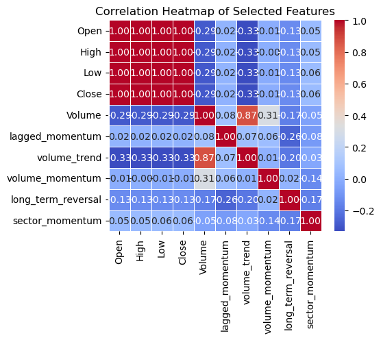

```python
correlation_matrix = X_train_selected.corr()

plt.figure(figsize=(5, 4))
sns.heatmap(correlation_matrix, annot=True, fmt=".2f", cmap='coolwarm', linewidths=0.5)
plt.title('Correlation Heatmap of Selected Features')
plt.show()
```

The model above selected more than 5 predictors, some of which are perfectly correlated. Ideally, we aim to prevent multicollinearity by eliminating redundant indicators. However, in our specific use case, correlated predictors can still be effective for predicting the next day's closing price. This is because financial markets are influenced by various factors that often move together. For example, `Open`, `High`, `Low`, and `Close` prices are naturally correlated because they are derived from the same trading day.

In this context, correlation can imply causation as these features are not only related but also influence each other directly. For instance, a high opening price can lead to higher closing prices, and high trading volumes can indicate market sentiment that drives prices. Including these correlated features enhances the model's ability to capture these causal relationships and the intricate patterns within the data, thus improving its predictive power.

Even though we eventually use a linear model, which is generally sensitive to multicollinearity, the inclusion of correlated predictors in our feature selection phase helps in identifying the most significant signals. During the training of the linear model, techniques such as regularization (Ridge regression) can mitigate the impact of multicollinearity, allowing us to retain the predictive benefits of correlated features while ensuring model stability and performace. .

## 4. Model Development

We will develop machine learning models to predict market trends using the engineered features. The models will be trained and validated using historical data.

We will train and hyperparameter tune our model. I have setup data pipelines to prevent any data leakages from the test data into the training process. I also make sure that the `RandomSearchCV` hyperparameter tuner utilizes cross-validation when fitting and experimenting with model parameters. This way I can ensure that I prevent overfitting and I do not get overly optimistic results.

```python
def train_and_evaluate_model(X_train, y_train, X_test, y_test, model, param_dist, cv, scoring='r2', model_filename='best_model.pkl'):
    pipeline = Pipeline(steps=[
        ('regressor', model)
    ])

    random_search = RandomizedSearchCV(
        pipeline,
        param_distributions=param_dist,
        n_iter=100,
        cv=cv,
        scoring=scoring,
        random_state=42,
        n_jobs=-1  # Use all available cores
    )

    random_search.fit(X_train, y_train)
    best_params = random_search.best_params_
    best_score = random_search.best_score_
    print(f"Best parameters for {model.__class__.__name__}:", best_params)
    print(f"Best cross-validation score for {model.__class__.__name__}:", best_score)

    y_pred = random_search.best_estimator_.predict(X_test)
    test_score = r2_score(y_test, y_pred)
    test_mse = mean_squared_error(y_test, y_pred)

    print(f"Test set R² score for {model.__class__.__name__}:", test_score)
    print(f"Test set MSE score for {model.__class__.__name__}:", test_mse)
    print("\n")

    joblib.dump(random_search.best_estimator_, model_filename)

    return random_search.best_estimator_, best_params, best_score, test_score
```

```python
param_dist_lr = {}
param_dist_ridge = {
    'regressor__alpha': [0.01, 0.1, 1.0, 10.0, 100.0]
}

param_dist_rf = {
    'regressor__n_estimators': [1, 2, 3, 4, 5],
    'regressor__max_depth': [3, 5, 7]
}

param_dist_gb = {
    'regressor__n_estimators': [5, 10, 20, 25],
    'regressor__learning_rate': [0.01, 0.1, 0.15],
    'regressor__max_depth': [3, 5, 7]
}

param_dist_xgb = {
    'regressor__n_estimators': [5, 10, 20, 25],
    'regressor__learning_rate': [0.01, 0.1, 0.15],
    'regressor__max_depth': [3, 5, 7]
}


# Linear Regression model
best_lr, best_params_lr, best_score_lr, test_score_lr = train_and_evaluate_model(
    X_train_selected, y_train, X_test_selected, y_test, LinearRegression(), param_dist_lr, cv, model_filename='best_lr_model.pkl'
)

# Ridge Regression model
best_ridge, best_params_ridge, best_score_ridge, test_score_ridge = train_and_evaluate_model(
    X_train_selected, y_train, X_test_selected, y_test, Ridge(random_state=42), param_dist_ridge, cv, model_filename='best_ridge_model.pkl'
)

# RandomForestRegressor model
best_rf, best_params_rf, best_score_rf, test_score_rf = train_and_evaluate_model(
    X_train_selected, y_train, X_test_selected, y_test, RandomForestRegressor(random_state=42), param_dist_rf, cv, model_filename='best_rf_model.pkl'
)

# GradientBoostingRegressor model
best_gb, best_params_gb, best_score_gb, test_score_gb = train_and_evaluate_model(
    X_train_selected, y_train, X_test_selected, y_test, GradientBoostingRegressor(random_state=42), param_dist_gb, cv, model_filename='best_gb_model.pkl'
)

# XGBRegressor model
best_xgb, best_params_xgb, best_score_xgb, test_score_xgb = train_and_evaluate_model(
    X_train_selected, y_train, X_test_selected, y_test, xgb.XGBRegressor(objective='reg:squarederror', random_state=42), param_dist_xgb, cv, model_filename='best_xgb_model.pkl'
)
```

```
Best parameters for LinearRegression: {}
Best cross-validation score for LinearRegression: 0.9983687065897395
Test set R² score for LinearRegression: 0.9972457296538665
Test set MSE score for LinearRegression: 1.7239942644652835


Best parameters for Ridge: {'regressor__alpha': 100.0}
Best cross-validation score for Ridge: 0.9983715306557774
Test set R² score for Ridge: 0.997302990618498
Test set MSE score for Ridge: 1.6881526214177534


Best parameters for RandomForestRegressor: {'regressor__n_estimators': 5, 'regressor__max_depth': 7}
Best cross-validation score for RandomForestRegressor: 0.9979965895222609
Test set R² score for RandomForestRegressor: -2.750388378017309
Test set MSE score for RandomForestRegressor: 2347.4994247734685


Best parameters for GradientBoostingRegressor: {'regressor__n_estimators': 25, 'regressor__max_depth': 5, 'regressor__learning_rate': 0.15}
Best cross-validation score for GradientBoostingRegressor: 0.9978655730706679
Test set R² score for GradientBoostingRegressor: -3.118081322660167
Test set MSE score for GradientBoostingRegressor: 2577.6513154687705


Best parameters for XGBRegressor: {'regressor__n_estimators': 25, 'regressor__max_depth': 5, 'regressor__learning_rate': 0.15}
Best cross-validation score for XGBRegressor: 0.9977752788655601
Test set R² score for XGBRegressor: -3.1597071332802633
Test set MSE score for XGBRegressor: 2603.7063680758993
```

### Understanding the Results

The Linear Regression and Ridge Regression models perform exceptionally well, achieving high cross-validation and test set R² scores with low MSE scores. This suggests that the linear models are sufficient for capturing the relationships in our data.

- **Performance**: High test R² (0.997) and low MSE (1.68) indicate excellent generalization.
- **Regularization**: Ridge's L2 regularization helps mitigate overfitting.
- **Simplicity**: Linear models are computationally efficient and interpretable.

Complex models (Random Forest, Gradient Boosting, XGB) overfit the training data, evidenced by negative test R² scores and high MSEs, making them unsuitable for this dataset.

The Ridge model's ability to handle multicollinearity while maintaining simplicity and computational efficiency makes it the optimal choice for our predictive task. making it the optimal choice for this project.

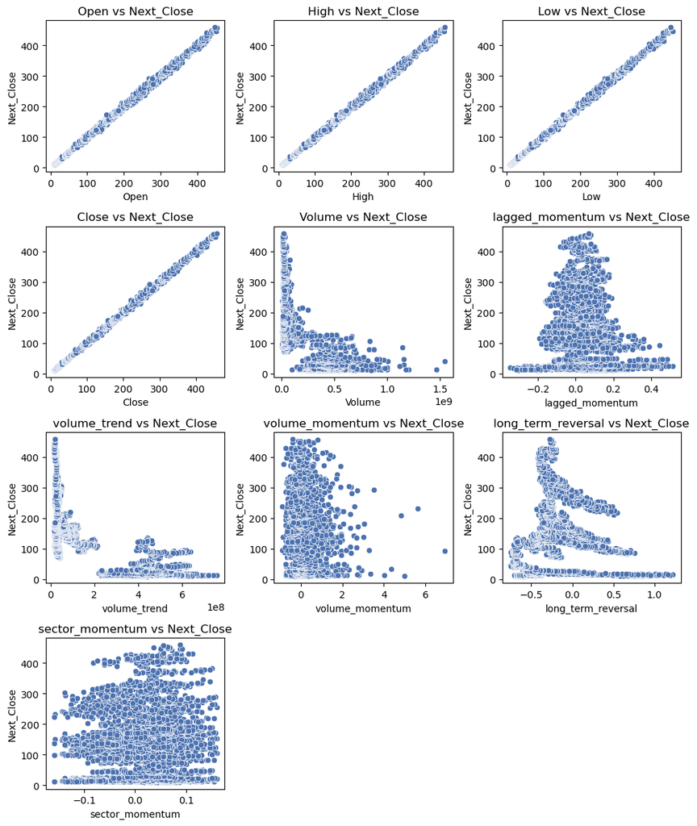

```python
def plot_features_grid(features, data, target='Next_Close', cols=3):
    rows = (len(features) + cols - 1) // cols
    fig, axes = plt.subplots(rows, cols, figsize=(10, 3 * rows))
    axes = axes.flatten()

    for i, feature in enumerate(features):
        sns.scatterplot(ax=axes[i], data=data, x=feature, y=target)
        axes[i].set_title(f'{feature} vs {target}')
        axes[i].set_xlabel(feature)
        axes[i].set_ylabel(target)

    # Hiding any unused subplots
    for j in range(i + 1, len(axes)):
        fig.delaxes(axes[j])

    plt.tight_layout()
    plt.show()

plot_features_grid(selected_features, combined_data)
```

The scatter plots above illustrate the relationships between each selected feature and the next day's closing price, affirming our choice of a linear model.

## 5. Backtesting

To evaluate our model's performance, I implemented a backtesting strategy using historical data. Here's a concise overview:

1. **Model Loading**: We load the trained model (`best_ridge_model.pkl`) using `joblib`.
2. **Feature Selection and Prediction**: For each stock, we select the relevant features and predict the next day's closing price.
3. **Trading Strategy**:
   - **Buy Setup**: If the predicted next day's close is higher than the current close, we simulate a buy. Return is calculated as `(next_close - current_close) / current_close`.
   - **Short Setup**: If the predicted next day's close is lower than the current close, we simulate a short. Return is `(current_close - next_close) / current_close`.
   - **No Trade**: If the predicted next day's close equals the current close, no trade is executed.
   - **Note**: Each day, we engage in two trades. We square off the trade executed on the day before, and we place a new trade today based on the Next Day's Close Price. To accomodate the two trade nature, I square off my position as I trade since I already have access to the Next Day's Close Price.
4. **Return Calculation**: Total returns from all trades are accumulated and annualized by dividing by the number of years (5 years).
5. **Multi-Stock Backtesting**: The process is repeated for each stock. Annualized returns for each stock are stored and reviewed.

#### Why This Approach?

- **Real-World Evaluation**: Backtesting with historical data evaluates the model's performance in real market conditions.
- **Trading Strategy Assessment**: Simulating buy and short setups helps assess the strategy's profitability and risk.
- **Standardized Metrics**: Annualized returns provide a clear comparison of performance across different stocks.

```python
def backtest_model(data, selected_features, model_filename='best_ridge_model.pkl'):

    best_model = joblib.load(model_filename)
    X = data[selected_features]
    y_pred = best_model.predict(X)

    total_return = 0.0

    for i in range(len(data) - 1):  # Avoiding the last row as we need the next day's actual close
        current_close = data['Close'].iloc[i]
        next_close = data['Close'].iloc[i + 1]
        predicted_next_close = y_pred[i]

        if predicted_next_close > current_close: # Buy Setup
            trade_return = (next_close - current_close) / current_close
        elif predicted_next_close < current_close: # Short Setup
            trade_return = (current_close - next_close) / current_close
        else:
            trade_return = 0

        total_return += trade_return

    annualized_return = total_return / 5

    return annualized_return

def perform_backtesting_on_all_stocks(data, selected_features, model_filename):
    annualized_returns = {}

    for stock in data.index.get_level_values(0).unique():
        stock_data = data.loc[stock].copy()
        annualized_return = backtest_model(stock_data, selected_features, model_filename)
        annualized_returns[stock] = annualized_return
        print(f"{stock} - Annualized Return: {annualized_return}")

    return annualized_returns

annualized_returns = perform_backtesting_on_all_stocks(combined_data, selected_features, 'best_ridge_model.pkl')
```

```
AAPL - Annualized Return: 0.2033017546368717
MSFT - Annualized Return: 0.18657324628458774
GOOG - Annualized Return: 0.30539242825201185
NVDA - Annualized Return: 0.33221935563643895
```

## 5. Portfolio Construction and Performance Evaluation

We will construct and simulate a weighted portfolio using the `PyPortfolioOpt` library. This involves:

Inputs required:

- **Annualized Returns**: Series, list, or array of annualized returns.
- **Covariance Matrix**: Derived from stock price data for risk effectively.

```python
def get_close_prices(ticker, start_date, end_date):
    stock = yf.Ticker(ticker)
    hist = stock.history(start=start_date, end=end_date)
    return hist['Close']

close_prices = pd.DataFrame({ticker: get_close_prices(ticker, start_date, end_date) for ticker in tickers})

close_prices.head()
```

| Date | AAPL | MSFT | GOOG | NVDA |
| --- | --- | --- | --- | --- |
| 2019-07-05 00:00:00-04:00 | 49.275452 | 130.713547 | 56.515186 | 3.982759 |
| 2019-07-08 00:00:00-04:00 | 48.259689 | 130.618179 | 55.754055 | 3.907692 |
| 2019-07-09 00:00:00-04:00 | 48.554039 | 130.141312 | 56.177574 | 3.910178 |
| 2019-07-10 00:00:00-04:00 | 49.034176 | 131.466965 | 56.959183 | 3.978534 |
| 2019-07-11 00:00:00-04:00 | 48.677090 | 131.991470 | 57.145470 | 4.133142 |

```python
volatility_matrix = risk_models.semicovariance(close_prices, benchmark=((1.0392**(1/252))-1))
annualized_returns_array = np.array(list(annualized_returns.values()))

ef = EfficientFrontier(annualized_returns_array, volatility_matrix)
raw_weights = ef.max_sharpe()
cleaned_weights = ef.clean_weights()
```

```python
custom_return, custom_volatility, custom_sharpe_ratio = ef.portfolio_performance(verbose=True)
```

```
Expected annual return: 30.5%
Annual volatility: 21.9%
Sharpe Ratio: 1.30
```

```python
stock = yf.Ticker("^GSPC")
hist = stock.history(start=start_date, end=end_date)
close_prices_sp500 = hist['Close']

close_prices_sp500.head()
```

```
Date
2019-07-05 00:00:00-04:00    2990.409912
2019-07-08 00:00:00-04:00    2975.949951
2019-07-09 00:00:00-04:00    2979.629883
2019-07-10 00:00:00-04:00    2993.070068
2019-07-11 00:00:00-04:00    2999.909912
Name: Close, dtype: float64
```

```python
annualized_returns_sp500 = expected_returns.mean_historical_return(close_prices_sp500)
volatility_matrix_sp500 = risk_models.semicovariance(close_prices_sp500, benchmark=((1.0392**(1/252))-1))

ef_sp500 = EfficientFrontier(annualized_returns_sp500, volatility_matrix_sp500)

sp_raw_weights = ef_sp500.max_sharpe()
sp_cleaned_weights = ef_sp500.clean_weights()
```

```python
sp_return, sp_volatility, sp_sharpe_ratio = ef_sp500.portfolio_performance(verbose=True)
```

```
Expected annual return: 13.0%
Annual volatility: 15.3%
Sharpe Ratio: 0.72
```

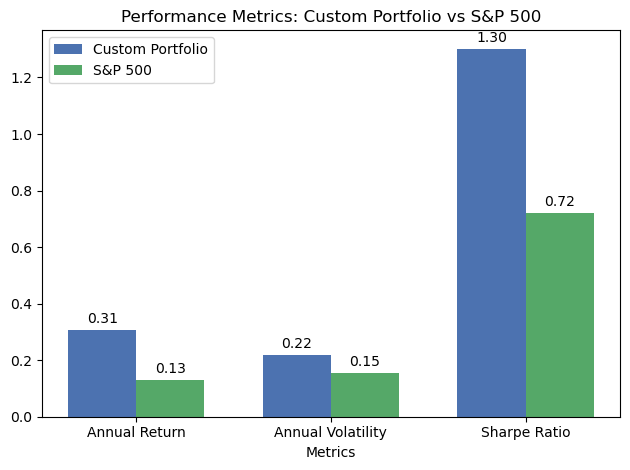

```python
# Custom Portfolio Metrics
custom_metrics = {
    'Annual Return': custom_return,
    'Annual Volatility': custom_volatility,
    'Sharpe Ratio': custom_sharpe_ratio
}

# S&P 500 Metrics
sp500_metrics = {
    'Annual Return': sp_return,
    'Annual Volatility': sp_volatility,
    'Sharpe Ratio': sp_sharpe_ratio
}

metrics = list(custom_metrics.keys())
custom_values = list(custom_metrics.values())
sp500_values = list(sp500_metrics.values())

x = np.arange(len(metrics))
width = 0.35

fig, ax = plt.subplots()

rects1 = ax.bar(x - width/2, custom_values, width, label='Custom Portfolio')
rects2 = ax.bar(x + width/2, sp500_values, width, label='S&P 500')

ax.set_xlabel('Metrics')
ax.set_title('Performance Metrics: Custom Portfolio vs S&P 500')
ax.set_xticks(x)
ax.set_xticklabels(metrics)
ax.legend()

def autolabel(rects):
    for rect in rects:
        height = rect.get_height()
        ax.annotate(f'{height:.2f}',
                    xy=(rect.get_x() + rect.get_width() / 2, height),
                    xytext=(0, 3),  # 3 points vertical offset
                    textcoords="offset points",
                    ha='center', va='bottom')

autolabel(rects1)
autolabel(rects2)

fig.tight_layout()
plt.show()
```

## 6. Performance Analysis: Custom Portfolio vs S&P 500

- **Annual Return**: The custom portfolio achieves a significantly higher annual return (31%) compared to the S&P 500 (13%). This indicates the custom portfolio's strong performance in generating returns.
- **Annual Volatility**: The custom portfolio has higher volatility (22%) compared to the S&P 500 (15%), reflecting increased risk.
- **Sharpe Ratio**: The custom portfolio's Sharpe Ratio (1.30) is notably higher than the S&P 500's (0.72), indicating better risk-adjusted returns. Despite higher volatility, the custom portfolio provides superior returns per unit of risk.

#### Alpha and Beta under CAPM

- Alpha measures the active return on an investment compared to a market index or benchmark, indicating the value added (or subtracted) by an investment manager.
- Beta measures the sensitivity of a portfolio's returns to market movements, indicating its systematic risk.

**Formula**: $$ \alpha = R_i - \left( R_f + \beta \times (R_m - R_f) \right) $$

**Legend**:

- $\alpha$: Alpha (Excess Returns)
- $R_i$: Return on my Portfolio
- $R_f$: Risk-free rate of return
- $\beta$: Beta
- $R_m$: Return of S&P 500 index

```python
risk_free_rate = 0.025 # Assumption

def get_stock_beta(ticker):
    stock = yf.Ticker(ticker)
    summary = stock.info
    return summary['beta']

stock_betas = {ticker: get_stock_beta(ticker) for ticker in tickers}
portfolio_beta = sum(cleaned_weights[ticker] * stock_betas[ticker] for ticker in tickers)
alpha = custom_return - (risk_free_rate + portfolio_beta * (sp_return - risk_free_rate))

print(f"Portfolio Beta: {portfolio_beta:.4f}")
print(f"Portfolio Alpha: {alpha:.4f}")
```

```
Portfolio Beta: 1.0460
Portfolio Alpha: 0.1701
```

- **Portfolio Beta (1.0460)**: A beta close to 1 indicates that the portfolio's systematic risk is similar to the market's risk. In this case, the custom portfolio is 1.046 times more volatile than the market. Thus, for every 1% move by the market, the portfolio moves approximately 1.046%. This suggests that the portfolio's risk is comparable to the market's risk.
- **Portfolio Alpha (0.1701)**: The custom portfolio has an alpha of 0.1701, suggesting that it has outperformed the benchmark (S&P 500) by approximately 17.01% on a risk-adjusted basis. This positive alpha indicates that the investment strategy has added value beyond what would be expected based on its beta.

## 7. Conclusion and Next Steps

**Areas for Improvement:**

- **Utilize Multiple Data Sources**: Incorporate additional data sources to assess all market and event signals from the McLean and Pontiff (2016) research.
- **Implement Sentiment Analysis**: Use Natural Language Processing (NLP) to analyze sentiment from news sources to enhance signal assessment.
- **Refine Model Training and Testing**: Train the model on a 3-year period and test it on a 5-year period for more robust performance evaluation.
- **Develop Trading Strategies**: Devise trading strategies using the selected signals and predicted close prices. The predicted close prices can serve as price levels for trading scenarios.